# BiocWorkshops2019

# Orchestrating Single-Cell Analysis with Bioconductor: Workshop

## Instructors names and contact information

- Robert A. Amezquita[^1] (robert.amezquita@fredhutch.org)
- Stephanie C. Hicks[^2] (shicks19@jhu.edu)

## Workshop Description

This workshop gives an introductory overview of analyzing single-cell data, particularly RNA-seq, using Bioconductor software. This workshop will help participants to understand essential Bioconductor infrastructure, such as the *SingleCellExperiment* class, and various analytical routines using real-world data. Finally, this workshop is modeled after the manuscript *“Orchestrating Single-Cell Analysis with Bioconductor”* (Amezquita et al. 2019). Students will analyze provided example datasets on their personal laptop. This workshop will be a mixture of example code shown by instructors (available through this repository), short exercises, and discussion.

## Pre-requisites

- Basic knowledge of R syntax
- Some familiarity with S4 objects may be helpful, but is not required
- Some familiarity with tidyverse syntax and methods, such as the usage of pipes, may be helpful, but is not required
- Familiarity with high-throughput gene expression data as obtained from RNA-seq; familiarity with single-cell RNA-seq helpful, but not required

Relevant background reading:

- (Amezquita et al. 2019)

In this workflow, we will be using the [`TENxPBMCData` package’s 3k cell dataset](https://bioconductor.org/packages/release/data/experiment/html/TENxPBMCData.html). This dataset contains various cell types, and is small enough to demonstrate essential Bioconductor packages and workflows.

## Workshop Participation

Students will be able to run code interactively during the workshop on their personal computers during a live demonstration of the code used herein, with ample opportunity for questions, answers, and discussion.

## *R* / *Bioconductor* packages used

```r
if (!requireNamespace("BiocManager", quietly = TRUE))
    install.packages("BiocManager")
BiocManager::install(version = "3.10")

BiocManager::install(c(
                 'TENxPBMCData',    # dataset
                 'DropletUtils',    # quality control
                 'scater', 'scran', # normalization/downstream analysis/viz
                 'iSEE',            # interactive viz (not run)
                 'BiocParallel',    # faster computation
                 'devtools',        # for installing cellassign
                 'tidyr',           # data munging
                 'tensorflow'))     # cellassign dependency

## optional for annotation section:
devtools::install_github('irrationone/cellassign') # automated annotation of cells
```

- SingleCellExperiment
- scater
- TENxPBMCData
- DropletUtils)
- scater
- scran
- [igraph](https://igraph.org/r/)
- devtools
- [tidyr](https://tidyr.tidyverse.org)
- [tensorflow](https://tensorflow.rstudio.com)
- cellassign

```r
    library(tidyr)
    library(BiocParallel)
    library(iSEE)
    library(TENxPBMCData)
    library(DropletUtils)
    library(scater)
    library(scran)
```

## Time outline

50 min workshop consisting of the following:

| Activity | Time |
| --- | --- |
| Introduction to Workshop | 5m |
| Infrastructure: the SingleCellExperiment class | 10m |
| Framework of Single-Cell RNA-seq analysis | 10m |
| Data processing (QC, Norm, Feature Selection) | 10m |
| Downstream: Clustering, DE, Annotation | 10m |
| Sharing Data: Interactive Analysis | 5m |

## Workshop goals and objectives

### Learning goals

- Describe the framework needed to implement a basic single-cell RNA-seq analysis
- Describe the utility and design of the *SingleCellExperiment* object in the context of the analysis framework
- Identify critical steps within a typical single-cell RNA-seq analysis that can greatly influence end-results

### Learning objectives

- Import single-cell RNA-seq data from raw counts into a *SingleCellExperiment* object
- Utilize the *SingleCellExperiment* object for annotation, subsetting, and processing via ad-hoc and established methods
- Produce descriptive plots from *SingleCellExperiment* objects to evaluate key quality control and processing steps
- Perform a basic end-to-end analysis of a simple yet heterogeneous scRNA-seq dataset

## Overview of the SingleCellExperiment Class

The *SingleCellExperiment* class is a lightweight data container for storing data from single-cell assays or experiments that benefits from continual validity checks to prevent malformed data input. This has made the *SingleCellExperiment* data container the foundation of many packages oriented toward single-cell analysis available in Bioconductor, providing seamless interoperability between packages and facilitating the development and usage of cutting-edge computational methods. The *SingleCellExperiment* class was developed as an extension of the existing *SummarizedExperiment* class originally designed for bulk assays. In addition to supporting many existing software packages, *SingleCellExperiment* provides convenient methods and data structures that are specific to single-cell analyses.

The *SingleCellExperiment* object is organized into components, which are written to and accessed programmatically with *accessors* named after their corresponding component. Primary data, such as count matrices representing sequencing read or unique molecular identifier (UMI) counts, are stored in the *assays* component as one or more matrices (including sparse or dense matrices e.g. using the *Matrix* package), where rows represent features (e.g. genes, transcripts, genomic regions) and columns represent cells. Furthermore, each row and column can be annotated with a rich set of metadata. For example, row metadata are stored in the *rowData* component and could contain alternative gene id mappings, such as Entrez gene IDs alongside HUGO gene symbols. Furthermore, for rows corresponding to potentially disjoint genomic features, a special *rowRanges* component can be created to hold sets of genomic coordinates. Column metadata is stored in the *colData* component and contains information pertinent to cell-level characteristics. In particular, the data within the *colData* component can be used for subsetting of the *SingleCellExperiment* object, such as removing poor quality cells. An additional feature of the *SingleCellExperiment* class is the *reducedDims* component, which contains low-dimensional representations of data such as Principal Components Analysis (PCA), t-Distributed Stochastic Neighbor Embedding (t-SNE), and Uniform Manifold Approximation and Projection (UMAP).

Because all of the primary data, transformations of the data, and associated metadata reside in a single *SingleCellExperiment* object, this design feature enables the continual validity checking that assures data integrity as well as functional cross-references for each cell across all (meta)data characteristics. To enable analyses in computing environments where the data are too large to fit into memory, disk-backed representations of the data (e.g. HDF5) are supported in the *SingleCellExperiment* class.

## A Common Framework for Analyzing Single-Cell RNA-seq data

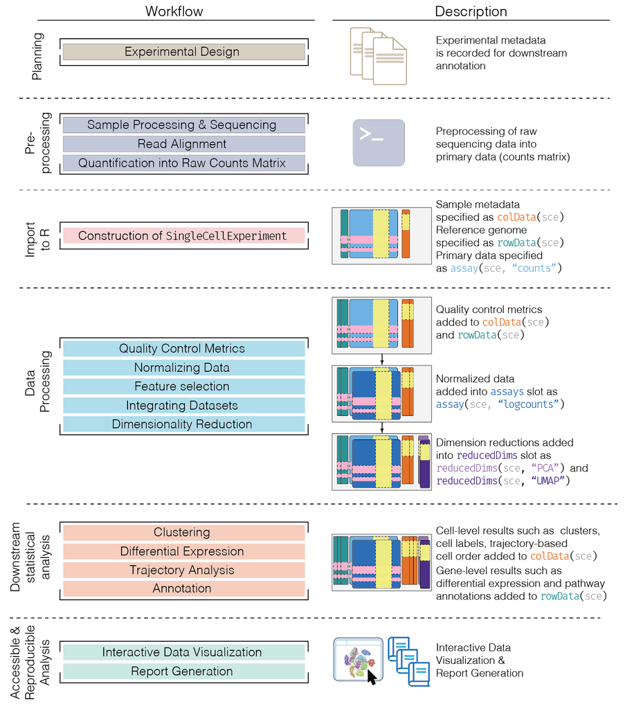

The framework of the analytical portion following preprocessing can be divided conceptually into three sections:

- *Data Processing*: these steps ultimately lead to the creation of a *clean* expression matrix, which in general serves as the common basis for most downstream analysis. This also includes the calculation of *reduced dimension* representations derived from the clean expression matrix, such as PCA, t-SNE, and UMAP, that are often used in downstream analysis and results visualization.
- *Downstream Analysis*: the choice of analysis hereafter are typically performed in service of answering a biological objective, and thus are not necessarily a linear series of steps as in data processing (the possible exception to this being clustering, as it often serves as the basis for other analyses). A variety of analyses can be performed, ranging from differential expression, to trajectory analysis, to annotation tasks such as gene set enrichment analysis and cell labeling.
- *Accessible and Reproducible Analysis*: sharing the record of analysis - most of if not all of - can be shared via the *SingleCellExperiment* object created throughout the analysis above - can be shared with external collaborators via platforms such as *iSEE*.

Please note, the workflow demonstrated in this workshop is written with the aim of *simplicity*, and thus will likely require nontrivial tweaking of parameters or alternate methods in real-world analyses.

One note: in this workflow, we will be loading libraries as they become necessary to clearly link libraries to their respective functions, which usually runs counter to the norm of loading libraries first, at the top of the analysis script.

## Preprocessing & Import to R

We will assume here that sequencing alignment and quantification of the data into a counts matrix, as well as the subsequent import to R has already been performed since this is highly platform- or technology-dependent.

Note that for 10X Genomics data (which is used in this example workflow), the counts matrix and associated metadata (cell barcodes, data path, etc.) can be imported via the `DropletUtils` package’s `read10xCounts()` function. For data processed through `Salmon`/`Alevin`/`Kallisto`, we recommend checking out the `tximport`/`tximeta` Bioconductor packages. These are either imported as `SingleCellExperiment` or as a counts matrix which can be then coerced into a `SingleCellExperiment` object as demonstrated below.

## Constructing the SingleCellExperiment

### From Scratch

Below we show an example of creating a `SingleCellExperiment` class object from a counts matrix and associated experimental metadata.

```r
library(SingleCellExperiment)

## More realistic: read in your experimental design metadata
## If its per cell metadata, make sure it lines up with your
## counts matrix row IDs correctly
## my_metadata <- read.csv("my_metadata.csv")

## Example data
ncells <- 100
my_counts_matrix <- matrix(rpois(20000, 5), ncol = ncells)
my_metadata <- data.frame(genotype = rep(c('A', 'B'), each = 50),
                          experiment_id = 'Experiment1')

## Construct the sce object manually
sce <- SingleCellExperiment(assays = list(counts = my_counts_matrix),
                            colData = my_metadata)

## Manually adding a variable that is the same across all cells
colData(sce) <- cbind(colData(sce), date = '2020-01-01')

sce
```

```
## class: SingleCellExperiment
## dim: 200 100
## metadata(0):
## assays(1): counts
## rownames: NULL
## rowData names(0):
## colnames: NULL
## colData names(3): genotype experiment_id date
## reducedDimNames(0):
## spikeNames(0):
```

### From Publicly Available Data

From here on out, we will be working with a small example dataset from the `TENxPBMCData` Bioconductor package which has already been packaged into a `SingleCellExperiment` class object:

```r
library(TENxPBMCData)
sce <- TENxPBMCData('pbmc3k')
```

```r
sce
```

```
## class: SingleCellExperiment
## dim: 32738 2700
## metadata(0):
## assays(1): counts
## rownames(32738): ENSG00000243485 ENSG00000237613 ...
##   ENSG00000215616 ENSG00000215611
## rowData names(3): ENSEMBL_ID Symbol_TENx Symbol
## colnames: NULL
## colData names(11): Sample Barcode ... Individual Date_published
## reducedDimNames(0):
## spikeNames(0):
```

One decision that should be made early on in the analysis is what row identifier to identify genes. Depending on how the data is imported, the `rowData` component may already have additional annotation information, such as multiple row mappings. For our new `sce` object from the `pbmc3k` dataset, we can take a look at `rowData` to see our options:

```r
rowData(sce)
```

```
## DataFrame with 32738 rows and 3 columns
##                      ENSEMBL_ID  Symbol_TENx       Symbol
##                     <character>  <character>  <character>
## ENSG00000243485 ENSG00000243485   MIR1302-10           NA
## ENSG00000237613 ENSG00000237613      FAM138A      FAM138A
## ENSG00000186092 ENSG00000186092        OR4F5        OR4F5
## ENSG00000238009 ENSG00000238009 RP11-34P13.7 LOC100996442
## ENSG00000239945 ENSG00000239945 RP11-34P13.8           NA
## ...                         ...          ...          ...
## ENSG00000215635 ENSG00000215635   AC145205.1           NA
## ENSG00000268590 ENSG00000268590        BAGE5           NA
## ENSG00000251180 ENSG00000251180   CU459201.1           NA
## ENSG00000215616 ENSG00000215616   AC002321.2           NA
## ENSG00000215611 ENSG00000215611   AC002321.1           NA
```

We see that we could choose between `ENSEMBL_ID` (the default), `Symbol_TENx`, and `Symbol`. For ease of readability and subsetting, we will utilize the `Symbol_TENx` identifier as our object’s rownames, making it possible to subset the `sce` with gene symbols as in `sce["CD8A", ]`.

```r
rownames(sce) <- rowData(sce)$Symbol_TENx
```

Now, while this *seems* to work just fine, eventually we may run into an issue because we actually have duplicated row names here. Depending on how a downstream function is coded, this may cause an esoteric error to pop-up. In fact, here we have 95 duplicates based on the `Symbol_TENx` gene identifier mapping.

We can avoid future errors (and many headaches) by removing duplicates before any analysis:

```r
## counts dupes from top to bottom
dupes <- duplicated(rownames(sce))

## keep all the not (!) duplicated genes
sce <- sce[!dupes, ]
```

Keep in mind, the above is likely the most inelegant solution to the problem. Other methods could include, from the duplicated set of genes, choosing the one with the highest expression, aggregating the counts per cell, or keeping them all by adding an additional suffix to make the row names unique. Each has its own tradeoffs, so we leave this choice up to the diligent reader.

And one more bit of preprocessing to prevent a potential downstream error is to assign our columns proper names. We can grab the barcodes of each cell from `colData` and assign them as column names as follows:

```r
colnames(sce) <- sce$Barcode
```

## Data Processing

The aim of this section is to form the basis for more interesting downstream analyses. Thus, the objective here is to transform the data into a “clean” expression matrix that has been normalized and freed of technical artifacts, as well as a dimensionality reduction representation that can be used in subsequent analyses and visualization.

### Quality Control Metrics

The first step is to ensure that our dataset only contains viable cells, e.g. droplets that contain proper mRNA libraries.

One way to do that is to use the popular “knee plot”, which shows the relationship between the log rank vs the log total counts, and then calculate where the “knee” of the plot is. We use the `DropletUtils` package to demonstrate this in our example PBMC dataset.

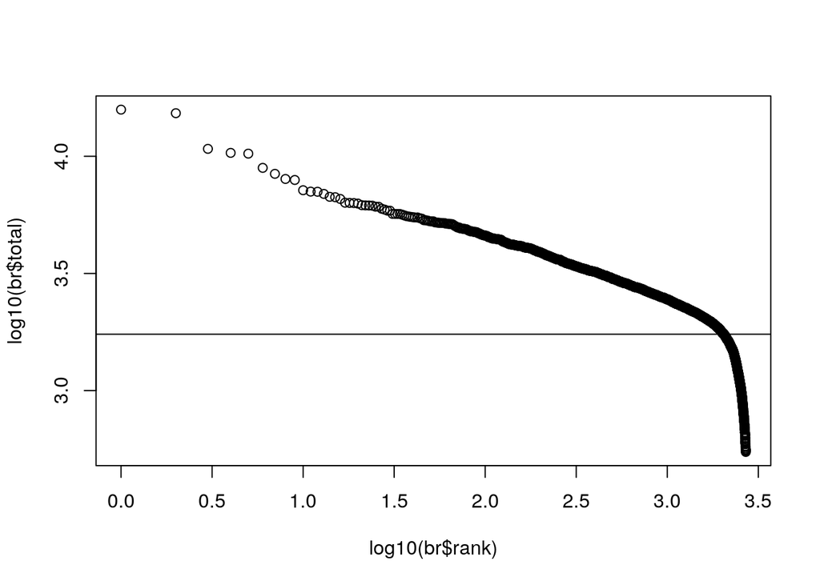

Figure 1: Barcode rank (aka knee) plot showing log10-rank by log10-total counts relationship and calculated knee (horizontal line).

```r
library(DropletUtils)

## Calculate the rank vs total counts per cell
br <- barcodeRanks(counts(sce))

## Create the knee plot
plot(log10(br$rank), log10(br$total))
abline(h = log10(metadata(br)$knee))
```

```r
## Save the calculated knee from `barcodeRanks()`
knee <- log10(metadata(br)$knee)
```

We see that the knee calculated via this method (horizontal line) is at 1740, or on the log scale, 3.2405.

This can be used as a filter to remove cells that are likely to be empty droplets. Before we do that, we will finish calculating other quality control (QC) metrics via the `scater` package and show the results from the first three cells.

```r
library(scater)

sce <- calculateQCMetrics(sce)
```

We can display some of the calculated QC metrics appended to the `colData` component - there are a number of other columns present, but for brevity will only show two pertinent ones.

```r
colData(sce)[1:3, c("log10_total_features_by_counts", "log10_total_counts")]
```

```
## DataFrame with 3 rows and 2 columns
##                  log10_total_features_by_counts log10_total_counts
##                                       <numeric>          <numeric>
## AAACATACAACCAC-1                           2.89               3.38
## AAACATTGAGCTAC-1                           3.13               3.69
## AAACATTGATCAGC-1                           3.05                3.5
```

We can further inspect these cells based on their total counts as well as vs the total features detected by counts (e.g. the number of genes that have nonzero counts).

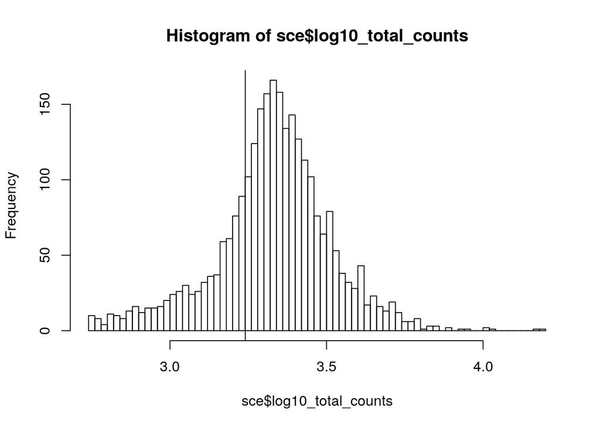

Figure 2: Histogram of the log10 total counts with the calculated knee from above (vertical line).

```r
hist(sce$log10_total_counts, breaks = 100)
abline(v = knee)
```

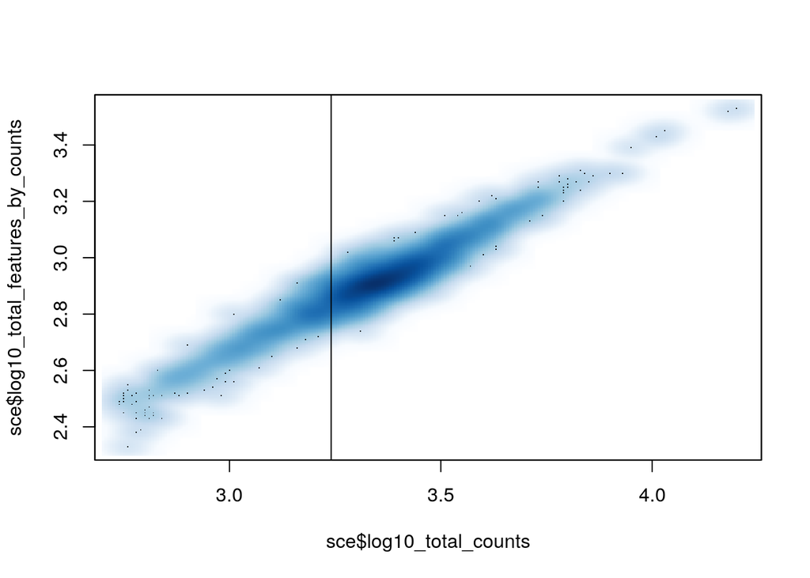

Figure 3: Smoothed scatter plot of the log10-total counts vs the log10-total features detected by counts with the calculated knee from above (vertical line).

```r
smoothScatter(sce$log10_total_counts, sce$log10_total_features_by_counts, nbin = 250)
abline(v = knee)
```

While there are various ways to filter cells, here we actually will not need to perform any filtering, as the data has already undergone a stringent quality control, and thus all the cells can be considered high quality.

For the sake of completeness, we will demonstrate here - without evaluating - how to subset based on the previously calculated barcode ranks knee:

```r
## not run
sce <- sce[, sce$log10_total_counts > knee]
```

### Normalizing Data

Next up we will transform the primary data, the counts, into a (log) normalized version. In this section, we will use the `scran` package throughout.

First however, we will need to calculate scaling factors per cell. This function relies on an initial “quick and dirty” clustering to get roughly similar pools of cells. These are used to generate pool-based estimates, from which the subsequent cell-based size factors are generated. To learn more about the method, see the `?computeSumFactors` documentation. Here we will use the `scran` package’s `quickCluster()` function to do the initial clustering.

```r
library(scran)

## not run: AMI hangs here
## quick_clusters <- quickCluster(sce, use.ranks = FALSE)
## sce <- computeSumFactors(sce, clusters = quick_clusters)
```

These (cell) size factors are then used to log-normalize the counts data:

```r
sce <- scater::normalize(sce)
```

```r
assays(sce)
```

```
## List of length 2
## names(2): counts logcounts
```

If we inspect our `sce`, we can see that we now have two assays, `counts` and `logcounts`.

### Feature Selection

This section will once again feature the `scran` package heavily, as we select for informative genes by selecting for those with high coefficients of biological variation.

Since this experiment does not have spike-ins, we will fit the mean-variance trend across the endogenous genes.

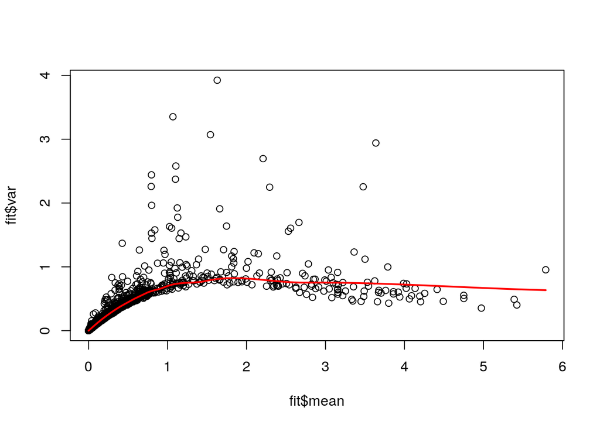

Figure 4: Mean-variance trend line fit by scran package trendVar() function.

```r
fit <- trendVar(sce, use.spikes = FALSE)

plot(fit$mean, fit$var)
curve(fit$trend(x), col = 'red', lwd = 2, add = TRUE)
```

We can see that the trend line goes through the central mass of genes, and thus continue on with looking at the decomposed variance. In this method, it is assumed that the total variance is the sum of the technical and biological variance, where the technical variance can be determined by interpolating the fitted trend at the mean log-count for that gene. Thus the biological variance is the total variance minus this interpolated (technical) variance.

We can then rank and choose genes which have a biological coefficient of variance greater than zero.

```r
dec <- decomposeVar(sce, fit)
dec <- dec[order(dec$bio, decreasing = TRUE), ] # order by bio var
```

```r
dec[1:5, ]
```

```
##          mean total   bio  tech p.value FDR
## LYZ     1.629 3.925 3.116 0.809       0   0
## S100A9  1.068 3.352 2.628 0.725       0   0
## HLA-DRA 1.543 3.071 2.278 0.793       0   0
## FTL     3.637 2.941 2.203 0.738       0   0
## CD74    2.209 2.696 1.900 0.796       0   0
```

The total number of genes with biological variance greater than zero as 3770.

Alternatively, we could use the p-value/FDR as a way to rank our genes, but do note the following (from the [`simpleSingleCell` vignette](https://bioconductor.org/packages/release/workflows/vignettes/simpleSingleCell/inst/doc/var.html#23_testing_for_significantly_positive_biological_components):

> “Ranking based on p-value tends to prioritize HVGs that are more likely to be true positives but, at the same time, less likely to be interesting. This is because the ratio can be very large for HVGs that have very low total variance and do not contribute much to the cell-cell heterogeneity.”

However we choose, we can save these highly variable genes and use them for subsequent analyses:

```r
## hvg_genes <- rownames(dec)[1:2000]
hvg_genes <- rownames(dec)[dec$bio > 0]
```

For the purpose of sharing and saving this list of genes, we can stash the result into the `metadata` component of our `sce` object as follows:

```r
metadata(sce)$hvg_genes <- hvg_genes
metadata(sce)$hvg_genes[1:10]
```

```
##  [1] "LYZ"     "S100A9"  "HLA-DRA" "FTL"     "CD74"    "CST3"    "S100A8"
##  [8] "TYROBP"  "NKG7"    "FTH1"
```

The `metadata` component can hold any object, as it is a list container. Any results that you’d like to keep are safe to store here, and a great way to save or share intermediate results that would otherwise be kept in separate objects.

### Dimensionality Reduction

We now can perform dimensionality reduction using our highly variable genes (`hvg_genes`) subset. To do this, we will first calculate the PCA representation via the `runPCA()` function from the `scater` package. We will calculate 50 components on our highly variable genes:

```r
sce <- runPCA(sce, ncomponents = 50,
              feature_set = hvg_genes)
```

The results of these calculations will be stored in the `reducedDims` component. This method saves the percent variance explained per component as an attribute, which can be accessed as follows, and subsequently plot the “elbow plot”:

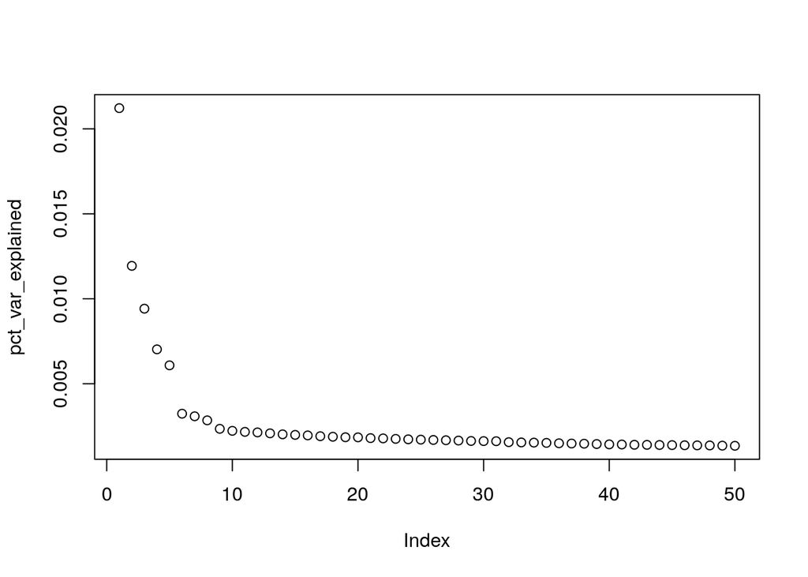

```r
## access the attribute where percentVar is saved in reducedDim
pct_var_explained <- attr(reducedDim(sce, 'PCA'), 'percentVar')

plot(pct_var_explained) # elbow plot
```

To calculate a 2-dimensional representation of the data, we will use the top 20 components of our PCA result to compute the UMAP representation.

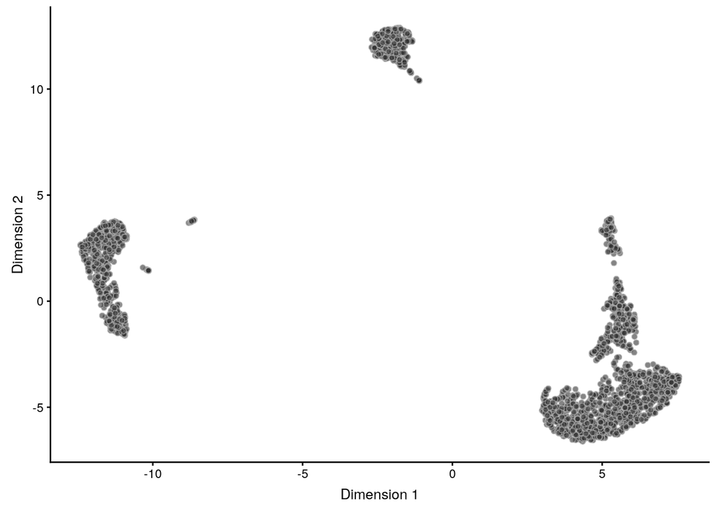

Figure 5: UMAP plot.

```r
sce <- runUMAP(sce, use_dimred = 'PCA', n_dimred = 20)

plotUMAP(sce)
```

With that, we have a canvas on which to paint our downstream analyses.

## Downstream Statistical Analyses

There are a plethora of potential downstream analyses to run, the choice of which is highly dependent on the biological objective. For this example dataset, our aim will be to identify the key cell types via a combination of clustering and differential expression.

### Clustering

Based on our earlier UMAP plot, it appears that we have a few distinct clusters. To do this computationally, we can utilize the `scran` package to:

- build a shared nearest neighbor (SNN) graph
- calculate based on the SNN graph the most representative clusters

In this first step, we will specify that we will consider `k` nearest neighbors, and `d` dimensions from the PCA calculation as follows:

```r
set.seed(1234) # to make results reproducible
snng <- buildSNNGraph(sce, k = 50, d = 20)
```

Following the graph construction, we can calculate the clusters using a variety of different graph-based methods from the `igraph` package. Here, we use the louvain method to determine our cell’s cluster memberships.

```r
set.seed(1234)
snng_clusters <- igraph::cluster_louvain(snng)
```

We see that we have the following numbers of cells per cluster:

```r
table(snng_clusters$membership)
```

```
##
##   1   2   3   4   5
## 687 350 556 528 579
```

To view this result graphically on the UMAP plot, we first assign the result to the `colData` component as a new column, and specify this as our color variable in the `plotUMAP()` function:

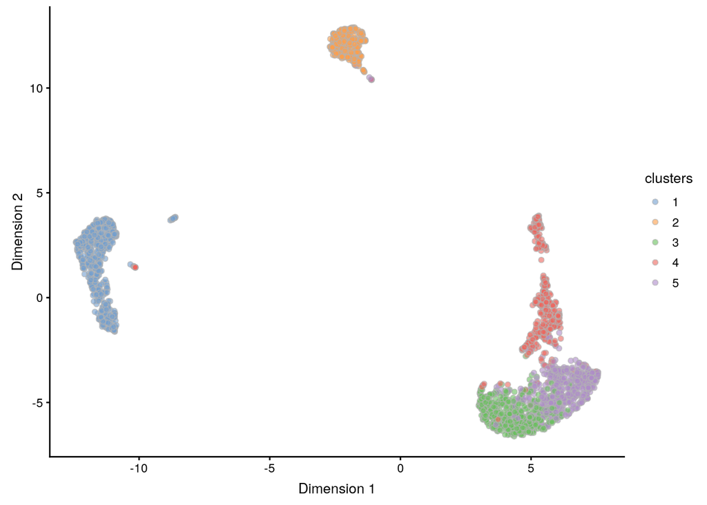

Figure 6: UMAP plot showing calculated clusters.

```r
colData(sce)$clusters <- as.factor(snng_clusters$membership)
plotUMAP(sce, colour_by = 'clusters')
```

Naturally, this result will change as we tweak the number of `k` neighbors to consider and with the specific clustering algorithm, but for now we will go onwards to find markers of each of our clusters.

### Differential Expression

In this section, we will look to identify genes that are unique to each of our clusters. To accomplish this, we will lean on the `scran` package to perform the analysis, and then the `scater` package to visualize the results.

For this analysis, we will limit ourselves to a top subset of highly variable genes in our `hvg_genes` set, purely for the sake of computation time. Furthermore, we will limit our consideration to genes with an *increased* log fold-change of at least 1.5 versus other clusters. We will also use the `BiocParallel` package to parallelize the computation and speed up our processing via the `BPPARAM` argument.

```r
markers <- findMarkers(sce, clusters = colData(sce)$clusters,
                       subset.row = hvg_genes[1:250],
                       lfc = 1.5, direction = 'up', log.p = TRUE,
                       BPPARAM = BiocParallel::MulticoreParam(1))
```

We can view the top 5 markers that are differentially expressed (by our specified metrics):

```r
markers[[1]][1:5, ]
```

```
##        Top log.p.value log.FDR logFC.2 logFC.3 logFC.4 logFC.5
## CST3     1      -831.4  -825.9   3.446   3.470   3.413   3.480
## TYROBP   1      -778.7  -773.8   3.325   3.324   2.691   3.301
## LYZ      2      -526.9  -522.8   4.028   4.011   4.072   4.000
## FTL      3      -667.3  -662.9   3.110   3.634   3.463   3.534
## FTH1     4      -474.3  -470.6   2.771   3.118   3.100   2.755
```

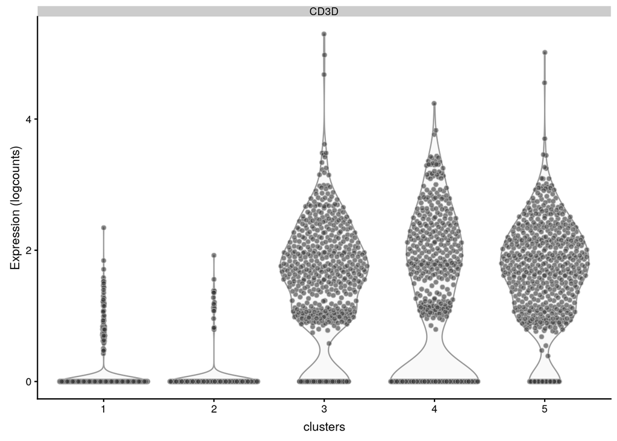

Figure 7: Violin plots of CD3D expression across clusters.

```r
plotExpression(sce, 'CD3D', x = 'clusters')
```

### Annotation

#### A Manual Approach

To finish off our the downstream analysis section here, we will look to annotate our clusters with a cell type designation, based on publicly available knowledge.

Before we do that, let’s get a broader view of our top differentially expressed genes. To do this, we can iterate over the list-object returned by `findMarkers` to get the top 10 genes per cluster, and then plot these genes in a heatmap.

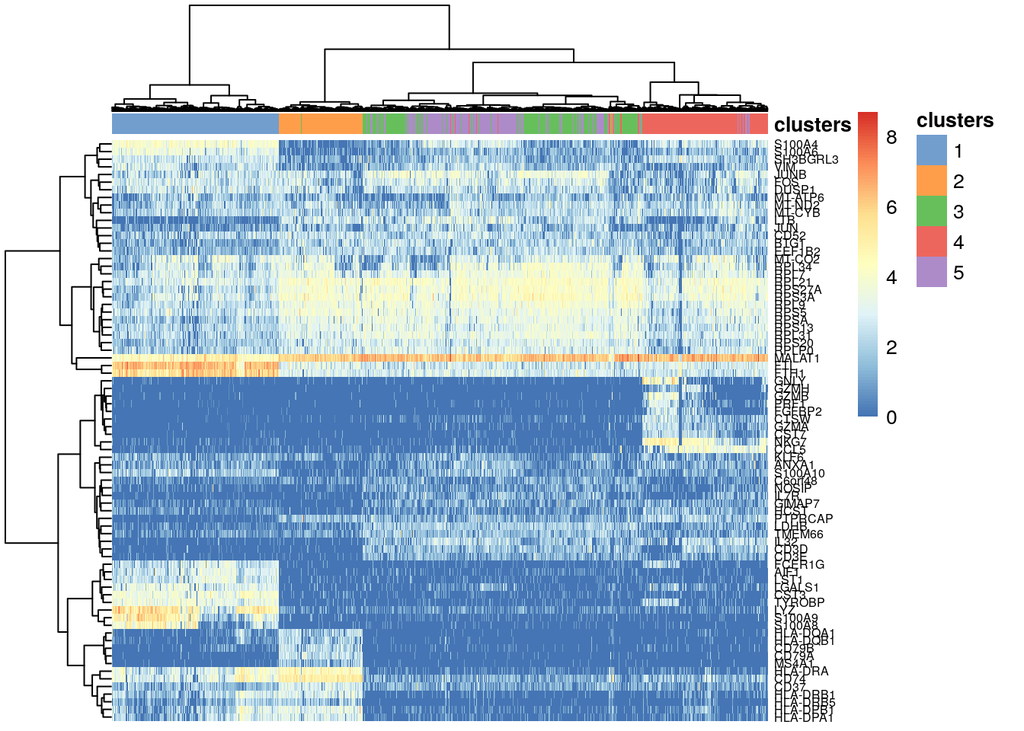

Figure 8: Heatmap showing top differentially expressed genes across the clusters.

```r
## grab the top 10 genes per cluster (e.g. within each list component)
genes <- lapply(markers, function(x) {
    rownames(x)[x$Top <= 10]
})

## uniqify the set of genes returned, after coercing to a vector
genes <- unique(unlist(genes))

plotHeatmap(sce, genes,
            colour_columns_by = "clusters",
            show_colnames = FALSE,
            clustering_method = 'ward.D2',
            fontsize_row = 6)
```

Finally, we can view a selection of the genes mentioned above on our previous UMAP plot:

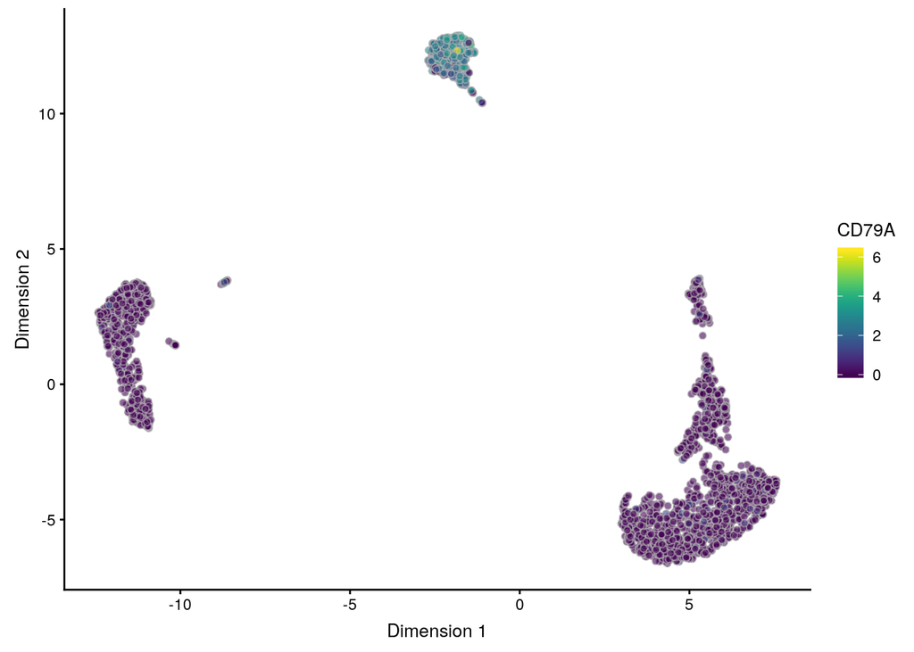

Figure 9: Various UMAP plots showing the expression of select cell-type specific genes.

```r
plotUMAP(sce, colour_by = "CD79A")
```

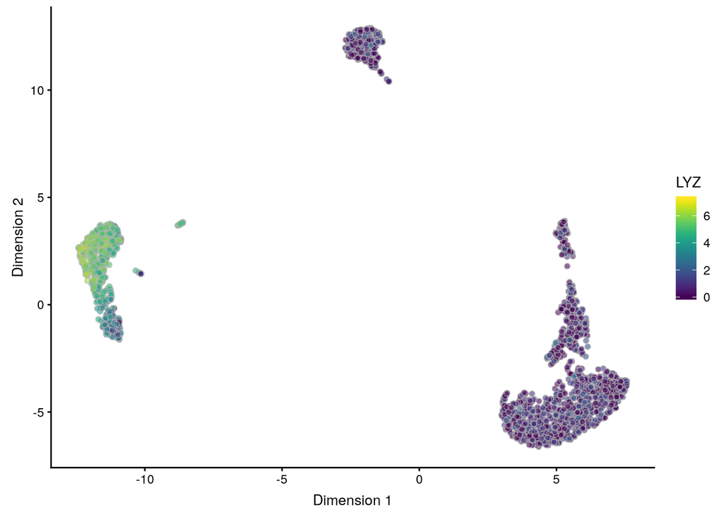

Figure 10: Various UMAP plots showing the expression of select cell-type specific genes.

```r
plotUMAP(sce, colour_by = "LYZ")
```

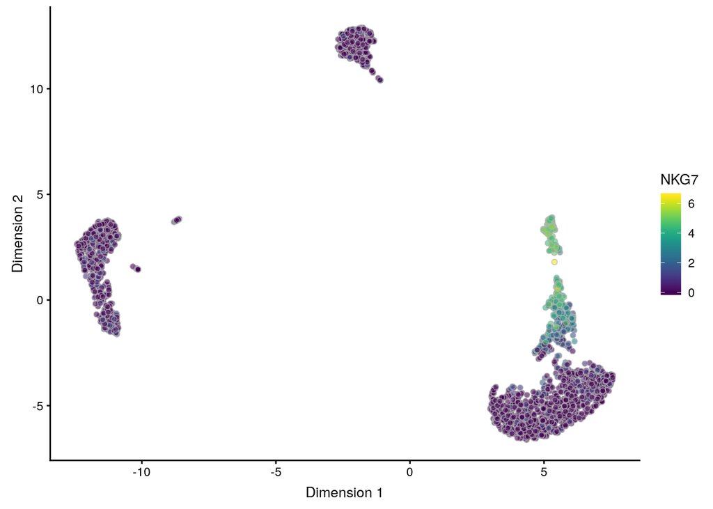

Figure 11: Various UMAP plots showing the expression of select cell-type specific genes.

```r
plotUMAP(sce, colour_by = "NKG7")
```

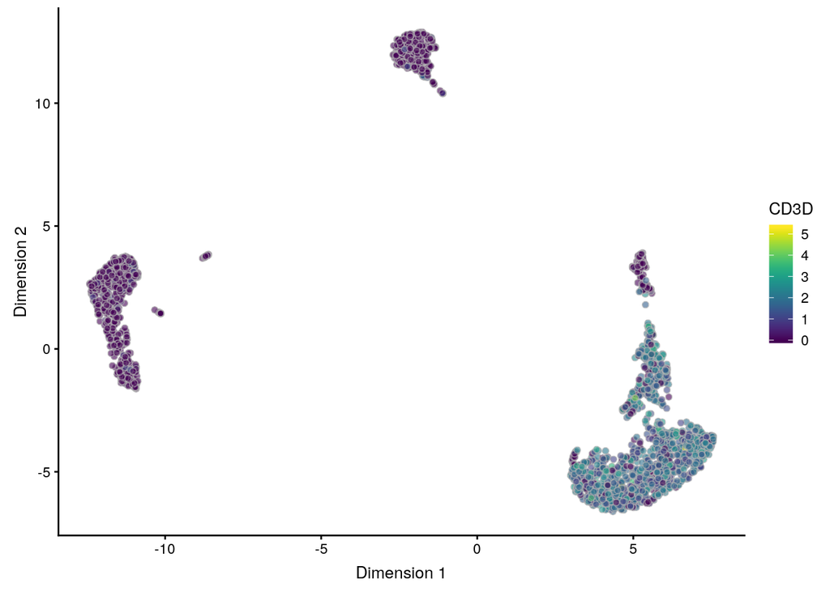

Figure 12: Various UMAP plots showing the expression of select cell-type specific genes.

```r
plotUMAP(sce, colour_by = "CD3D")
```

Now that we’ve manually sorted our dataset on the basis of prior knowledge, let’s try a more automated approach using publicly available markers.

#### An Automated Approach

Manually classifying cell types present in an scRNA-seq experiment can be prone to bias in terms of how a label is selected. Thus have emerged automated classification approaches which take a measured approach to the labeling of cell types.

One such approach - `cellassign` - applies labels in a single-cell manner based on a gene by cell type “marker matrix”. Here, we utilize an existing gene by cell type annotation from a publication by [Becht et al. (2016)](https://genomebiology.biomedcentral.com/articles/10.1186/s13059-016-1070-5) which categorizes genes into cell types based on the specificity of their expression.

Let’s first construct a marker matrix loosely inspired by the [Seurat PBMC 3k tutorial](https://satijalab.org/seurat/v3.0/pbmc3k_tutorial.html), with some of the manual markers defined above added in:

```r
anno <- data.frame(
    SYMBOL = c(
        'IL7R', 'CCR7', 'CD4', 'CD3D', 'CD3E',
        'CD14', 'LYZ',
        'MS4A1', 'CD79A', 'CD79B',
        'CD8A', 'CD8B', 'CD3D', 'CD3E',
        'GNLY', 'NKG7',
        'FCER1A', 'CST3', 'ITGAX'
    ),
    cell_type = c(
        rep('CD4 T cell', 5),
        rep('Monocyte', 2),
        rep('B cell', 3),
        rep('CD8 T cell', 4),
        rep('NK cell', 2),
        rep('Dendritic cell', 3)
    )
)
```

Lastly, we’ll need to reformat this matrix to fit the expectations of `cellassign`, converting the annotation into a binary matrix of genes (rows) by cell types (columns):

```r
## construct rho (binary marker matrix)
tmp <- tidyr::spread(anno, cell_type, cell_type)
rho <- ifelse(is.na(tmp[, -1]), 0, 1)
rownames(rho) <- tmp$SYMBOL

## remove entries that are not present in our dataset
rho <- rho[rownames(rho) %in% rownames(sce), ]

rho[1:3, ]
```

```
##      B cell CD4 T cell CD8 T cell Dendritic cell Monocyte NK cell
## CCR7      0          1          0              0        0       0
## CD14      0          0          0              0        1       0
## CD3D      0          1          1              0        0       0
```

We can then run the `cellassign` method to produce cell type labels on a per cell basis:

```r
## not run in vignette - results pulled from a prior run
## devtools::install_github('Irrationone/cellassign')
library(cellassign)
library(tensorflow)

set.seed(1234)
reticulate::py_set_seed(1234)
fit <- cellassign(sce[rownames(rho), ],
                  marker_gene_info = rho,
                  s = sizeFactors(sce))

## add cell type info into colData
colData(sce)$cellassign_type <- fit$cell_type
```

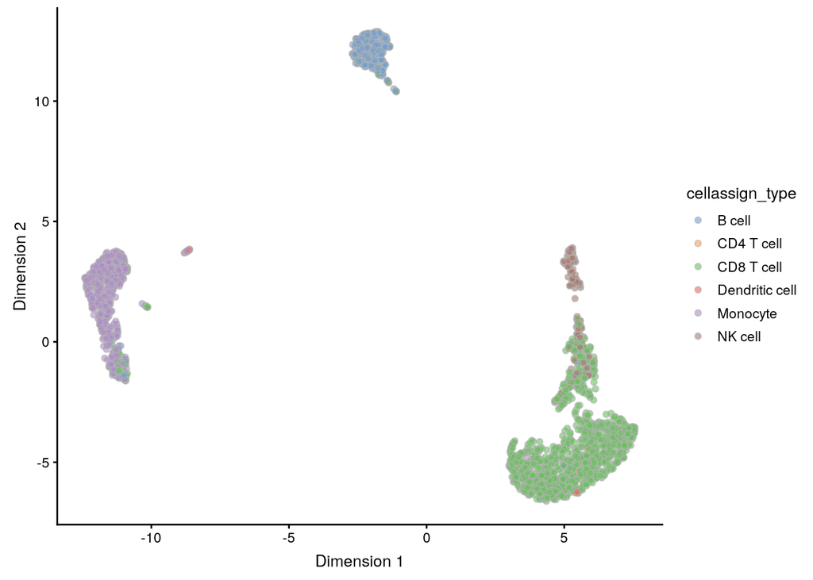

Figure 13: UMAP showing the results of automated label assignment as performed by cellassign.

```r
## plot the cellassign results on UMAP
plotUMAP(sce, colour_by = 'cellassign_type')
```

In practice, some combination of the above manual and automated classification schema will likely be necessary to properly annotate an scRNA-seq dataset.

## Accessible & Reproducible Analysis

In collaborative settings, it is essential to share data and analyses. Thanks to the `SingleCellExperiment` class, most of if not all analysis steps performed can be recorded. These outputs are accessible through not only R, but also via graphical user interfaces as well that broaden the potential viewing audience.

### Interactive Data Visualization

Interactive exploration and visualization is a great way for collaborators to learn more about scRNA-seq data and analyses. In particular the `iSEE` package has been especially designed for viewing and sharing scRNA-seq.

```r
## not run
library(iSEE)
iSEE(sce)
```

Based on the example analyses, we task the interested reader to assess the previous section’s automatic annotation relative to the clustering results using `iSEE`.

Amezquita, Robert A, Vince J Carey, Lindsay N Carpp, Ludwig Geistlinger, Aaron T L Lun, Federico Marini, Kevin Rue-Albrecht, et al. 2019. “Orchestrating Single-Cell Analysis with Bioconductor” 14 (9): e1006378–32.

[^1]: Fred Hutchinson Cancer Research Center, Seattle, WA, USA
[^2]: John Hopkins University, Dept. of Biostatistics, Baltimore, MD, USA